# classification-knn-adult-income

```python
import numpy as np
import pandas as pd
import matplotlib.pyplot as plt
from sklearn import preprocessing
import seaborn as sns
```

```python
df = pd.read_csv('adult_data.csv'
                 , names=['age',
                          'workclass',
                          'fnlwgt',
                          'education',
                          'education-num',
                          'marital-status',
                          'occupation',
                          'relationship',
                          'race',
                          'sex',
                          'capital-gain',
                          'capital-loss',
                          'hours-per-week',
                          'native-country',
                          'income'
                         ]
                 , header=None)
df.head()
```

|  | age | workclass | fnlwgt | education | education-num | marital-status | occupation | relationship | race | sex | capital-gain | capital-loss | hours-per-week | native-country | income |
| --- | --- | --- | --- | --- | --- | --- | --- | --- | --- | --- | --- | --- | --- | --- | --- |
| 0 | 39 | State-gov | 77516 | Bachelors | 13 | Never-married | Adm-clerical | Not-in-family | White | Male | 2174 | 0 | 40 | United-States | <=50K |
| 1 | 50 | Self-emp-not-inc | 83311 | Bachelors | 13 | Married-civ-spouse | Exec-managerial | Husband | White | Male | 0 | 0 | 13 | United-States | <=50K |
| 2 | 38 | Private | 215646 | HS-grad | 9 | Divorced | Handlers-cleaners | Not-in-family | White | Male | 0 | 0 | 40 | United-States | <=50K |
| 3 | 53 | Private | 234721 | 11th | 7 | Married-civ-spouse | Handlers-cleaners | Husband | Black | Male | 0 | 0 | 40 | United-States | <=50K |
| 4 | 28 | Private | 338409 | Bachelors | 13 | Married-civ-spouse | Prof-specialty | Wife | Black | Female | 0 | 0 | 40 | Cuba | <=50K |

```python
df.shape
```

```
(32561, 15)
```

```python
df['income'].unique()
```

```
array([' <=50K', ' >50K'], dtype=object)
```

```python
df['income'].value_counts()
```

```
 <=50K    24720
 >50K      7841
Name: income, dtype: int64
```

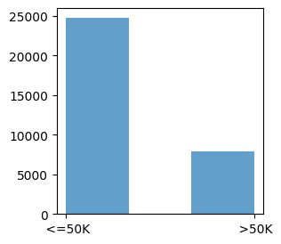

```python
plt.figure(figsize=(3,3))
plt.hist(df['income'],bins=3, alpha=0.7)
plt.show()
```

```python
df.isnull().values.any()
```

```
False
```

```python
df['income'] = df['income'].map({' <=50K' :0, ' >50K' :1}).astype(int) #mapping numbers
df.head()
```

|  | age | workclass | fnlwgt | education | education-num | marital-status | occupation | relationship | race | sex | capital-gain | capital-loss | hours-per-week | native-country | income |
| --- | --- | --- | --- | --- | --- | --- | --- | --- | --- | --- | --- | --- | --- | --- | --- |
| 0 | 39 | State-gov | 77516 | Bachelors | 13 | Never-married | Adm-clerical | Not-in-family | White | Male | 2174 | 0 | 40 | United-States | 0 |
| 1 | 50 | Self-emp-not-inc | 83311 | Bachelors | 13 | Married-civ-spouse | Exec-managerial | Husband | White | Male | 0 | 0 | 13 | United-States | 0 |
| 2 | 38 | Private | 215646 | HS-grad | 9 | Divorced | Handlers-cleaners | Not-in-family | White | Male | 0 | 0 | 40 | United-States | 0 |
| 3 | 53 | Private | 234721 | 11th | 7 | Married-civ-spouse | Handlers-cleaners | Husband | Black | Male | 0 | 0 | 40 | United-States | 0 |
| 4 | 28 | Private | 338409 | Bachelors | 13 | Married-civ-spouse | Prof-specialty | Wife | Black | Female | 0 | 0 | 40 | Cuba | 0 |

```python
df.describe()
```

|  | age | fnlwgt | education-num | capital-gain | capital-loss | hours-per-week | income |
| --- | --- | --- | --- | --- | --- | --- | --- |
| count | 32561.000000 | 3.256100e+04 | 32561.000000 | 32561.000000 | 32561.000000 | 32561.000000 | 32561.000000 |
| mean | 38.581647 | 1.897784e+05 | 10.080679 | 1077.648844 | 87.303830 | 40.437456 | 0.240810 |
| std | 13.640433 | 1.055500e+05 | 2.572720 | 7385.292085 | 402.960219 | 12.347429 | 0.427581 |
| min | 17.000000 | 1.228500e+04 | 1.000000 | 0.000000 | 0.000000 | 1.000000 | 0.000000 |
| 25% | 28.000000 | 1.178270e+05 | 9.000000 | 0.000000 | 0.000000 | 40.000000 | 0.000000 |
| 50% | 37.000000 | 1.783560e+05 | 10.000000 | 0.000000 | 0.000000 | 40.000000 | 0.000000 |
| 75% | 48.000000 | 2.370510e+05 | 12.000000 | 0.000000 | 0.000000 | 45.000000 | 0.000000 |
| max | 90.000000 | 1.484705e+06 | 16.000000 | 99999.000000 | 4356.000000 | 99.000000 | 1.000000 |

```python
df.isnull().sum()
```

```
age               0
workclass         0
fnlwgt            0
education         0
education-num     0
marital-status    0
occupation        0
relationship      0
race              0
sex               0
capital-gain      0
capital-loss      0
hours-per-week    0
native-country    0
income            0
dtype: int64
```

## data description:

age: continuous.

workclass: Private, ?, Self-emp-not-inc, Self-emp-inc, Federal-gov, Local-gov, State-gov, Without-pay, Never-worked.

it will be convert to new categories:

' Self-emp-not-inc' : 'self-employed',

' Self-emp-inc' : 'self-employed',

' Federal-gov' : 'gov', ' Local-gov' : 'gov', ' State-gov' : 'gov',

' Without-pay' : 'unemployed', ' Never-worked' : 'unemployed',

' Private' : ' Private',

' ?' : ' ?'.

fnlwgt (final weight): continuous. not neccesary. it will be droped.

education: Bachelors, Some-college, 11th, HS-grad, Prof-school, Assoc-acdm, Assoc-voc, 9th, 7th-8th, 12th, Masters, 1st-4th, 10th, Doctorate, 5th-6th, Preschool.

first of all it should be sorted: Preschool < 1st-4th < 5th-6th < 7th-8th < 9th < 10th < 11th < 12th < HS-grad < Prof-school < Assoc-acdm < Assoc-voc < Some-college < Bachelors < Masters < Doctorate

now, it will be convert to new categories:

' Preschool' :0, ' 1st-4th' :0, ' 5th-6th' :0, ' 7th-8th' :0, ' 9th' :0, ' 10th' :0, ' 11th' :0, ' 12th' :0,

' HS-grad' :1, ' Prof-school' :1,

' Assoc-acdm' :2, ' Assoc-voc' :2,

' Some-college' :3,

' Bachelors' :4,

' Masters' :5 ,

' Doctorate' :6

education-num: continuous. not neccesary. it will be droped.

marital-status: Married-civ-spouse, Divorced, Never-married, Separated, Widowed, Married-spouse-absent, Married-AF-spouse.

it will be convert to new categories:

' Married-civ-spouse' :"married", ' Married-AF-spouse' :"married",

' Never-married' :"not-married", ' Divorced' :"not-married", ' Separated' :"not-married", ' Married-spouse-absent' :"not-married",

' Widowed' :"Widowed"

occupation: Tech-support, Craft-repair, Other-service, Sales, Exec-managerial, Prof-specialty, Handlers-cleaners, Machine-op-inspct, Adm-clerical, Farming-fishing, Transport-moving, Priv-house-serv, Protective-serv, Armed-Forces.

it will be convert to new categories:

' Adm-clerical' :"adim", ' Exec-managerial' :"adim",

' Prof-specialty' :"Prof-specialty",

' Other-service' :"service", ' Protective-serv' :"service", ' Priv-house-serv' :"service",

' Sales' :"sales",

' Craft-repair' :"general", ' Transport-moving' :"general", ' Farming-fishing' :"general",

' Machine-op-inspct' :"general", ' Tech-support' :"general", ' Farming-fishing' :"general",

' Armed-Forces' :"military",

' ?':' ?'

race: White, Asian-Pac-Islander, Amer-Indian-Eskimo, Other, Black.

sex: Female, Male.

capital-gain: continuous.

capital-loss: continuous.

hours-per-week: continuous.

native-country: United-States, Cambodia, England, Puerto-Rico, Canada, Germany, Outlying-US(Guam-USVI-etc), India, Japan, Greece, South, China, Cuba, Iran, Honduras, Philippines, Italy, Poland, Jamaica, Vietnam, Mexico, Portugal, Ireland, France, Dominican-Republic, Laos, Ecuador, Taiwan, Haiti, Columbia, Hungary, Guatemala, Nicaragua, Scotland, Thailand, Yugoslavia, El-Salvador, Trinadad&Tobago, Peru, Hong, Holand-Netherlands.

```python
df.drop(['fnlwgt'], axis=1, inplace=True)
df
```

|  | age | workclass | education | education-num | marital-status | occupation | relationship | race | sex | capital-gain | capital-loss | hours-per-week | native-country | income |
| --- | --- | --- | --- | --- | --- | --- | --- | --- | --- | --- | --- | --- | --- | --- |
| 0 | 39 | State-gov | Bachelors | 13 | Never-married | Adm-clerical | Not-in-family | White | Male | 2174 | 0 | 40 | United-States | 0 |
| 1 | 50 | Self-emp-not-inc | Bachelors | 13 | Married-civ-spouse | Exec-managerial | Husband | White | Male | 0 | 0 | 13 | United-States | 0 |
| 2 | 38 | Private | HS-grad | 9 | Divorced | Handlers-cleaners | Not-in-family | White | Male | 0 | 0 | 40 | United-States | 0 |
| 3 | 53 | Private | 11th | 7 | Married-civ-spouse | Handlers-cleaners | Husband | Black | Male | 0 | 0 | 40 | United-States | 0 |
| 4 | 28 | Private | Bachelors | 13 | Married-civ-spouse | Prof-specialty | Wife | Black | Female | 0 | 0 | 40 | Cuba | 0 |
| ... | ... | ... | ... | ... | ... | ... | ... | ... | ... | ... | ... | ... | ... | ... |
| 32556 | 27 | Private | Assoc-acdm | 12 | Married-civ-spouse | Tech-support | Wife | White | Female | 0 | 0 | 38 | United-States | 0 |
| 32557 | 40 | Private | HS-grad | 9 | Married-civ-spouse | Machine-op-inspct | Husband | White | Male | 0 | 0 | 40 | United-States | 1 |
| 32558 | 58 | Private | HS-grad | 9 | Widowed | Adm-clerical | Unmarried | White | Female | 0 | 0 | 40 | United-States | 0 |
| 32559 | 22 | Private | HS-grad | 9 | Never-married | Adm-clerical | Own-child | White | Male | 0 | 0 | 20 | United-States | 0 |
| 32560 | 52 | Self-emp-inc | HS-grad | 9 | Married-civ-spouse | Exec-managerial | Wife | White | Female | 15024 | 0 | 40 | United-States | 1 |

32561 rows × 14 columns

```python
df['workclass'].unique()
```

```
array([' State-gov', ' Self-emp-not-inc', ' Private', ' Federal-gov',
       ' Local-gov', ' ?', ' Self-emp-inc', ' Without-pay',
       ' Never-worked'], dtype=object)
```

```python
df['workclass'] = df['workclass'].map({' Self-emp-not-inc' : 'self-employed', ' Self-emp-inc' : 'self-employed',
                                       ' Federal-gov' : 'gov', ' Local-gov' : 'gov', ' State-gov' : 'gov',
                                       ' Without-pay' : 'unemployed', ' Never-worked' : 'unemployed',
                                       ' Private' : ' Private', ' ?' : ' ?'
                                      }).astype(str) #mapping numbers
df.head()
```

|  | age | workclass | education | education-num | marital-status | occupation | relationship | race | sex | capital-gain | capital-loss | hours-per-week | native-country | income |
| --- | --- | --- | --- | --- | --- | --- | --- | --- | --- | --- | --- | --- | --- | --- |
| 0 | 39 | gov | Bachelors | 13 | Never-married | Adm-clerical | Not-in-family | White | Male | 2174 | 0 | 40 | United-States | 0 |
| 1 | 50 | self-employed | Bachelors | 13 | Married-civ-spouse | Exec-managerial | Husband | White | Male | 0 | 0 | 13 | United-States | 0 |
| 2 | 38 | Private | HS-grad | 9 | Divorced | Handlers-cleaners | Not-in-family | White | Male | 0 | 0 | 40 | United-States | 0 |
| 3 | 53 | Private | 11th | 7 | Married-civ-spouse | Handlers-cleaners | Husband | Black | Male | 0 | 0 | 40 | United-States | 0 |
| 4 | 28 | Private | Bachelors | 13 | Married-civ-spouse | Prof-specialty | Wife | Black | Female | 0 | 0 | 40 | Cuba | 0 |

```python
df['education'].unique()
```

```
array([' Bachelors', ' HS-grad', ' 11th', ' Masters', ' 9th',
       ' Some-college', ' Assoc-acdm', ' Assoc-voc', ' 7th-8th',
       ' Doctorate', ' Prof-school', ' 5th-6th', ' 10th', ' 1st-4th',
       ' Preschool', ' 12th'], dtype=object)
```

```python
df['education'] = df['education'].map({' Preschool' :0, ' 1st-4th' :0, ' 5th-6th' :0, ' 7th-8th' :0, ' 9th' :0, ' 10th' :0, ' 11th' :0, ' 12th' :0, ' HS-grad' :1, ' Prof-school' :1, ' Assoc-acdm' :2, ' Assoc-voc' :2, ' Some-college' :3, ' Bachelors' :4, ' Masters' :5 , ' Doctorate' :6}).astype(int) #mapping numbers
df.head()
```

|  | age | workclass | education | education-num | marital-status | occupation | relationship | race | sex | capital-gain | capital-loss | hours-per-week | native-country | income |
| --- | --- | --- | --- | --- | --- | --- | --- | --- | --- | --- | --- | --- | --- | --- |
| 0 | 39 | gov | 4 | 13 | Never-married | Adm-clerical | Not-in-family | White | Male | 2174 | 0 | 40 | United-States | 0 |
| 1 | 50 | self-employed | 4 | 13 | Married-civ-spouse | Exec-managerial | Husband | White | Male | 0 | 0 | 13 | United-States | 0 |
| 2 | 38 | Private | 1 | 9 | Divorced | Handlers-cleaners | Not-in-family | White | Male | 0 | 0 | 40 | United-States | 0 |
| 3 | 53 | Private | 0 | 7 | Married-civ-spouse | Handlers-cleaners | Husband | Black | Male | 0 | 0 | 40 | United-States | 0 |
| 4 | 28 | Private | 4 | 13 | Married-civ-spouse | Prof-specialty | Wife | Black | Female | 0 | 0 | 40 | Cuba | 0 |

```python
df.drop(['education-num'], axis=1, inplace=True)
df
```

|  | age | workclass | education | marital-status | occupation | relationship | race | sex | capital-gain | capital-loss | hours-per-week | native-country | income |
| --- | --- | --- | --- | --- | --- | --- | --- | --- | --- | --- | --- | --- | --- |
| 0 | 39 | gov | 4 | Never-married | Adm-clerical | Not-in-family | White | Male | 2174 | 0 | 40 | United-States | 0 |
| 1 | 50 | self-employed | 4 | Married-civ-spouse | Exec-managerial | Husband | White | Male | 0 | 0 | 13 | United-States | 0 |
| 2 | 38 | Private | 1 | Divorced | Handlers-cleaners | Not-in-family | White | Male | 0 | 0 | 40 | United-States | 0 |
| 3 | 53 | Private | 0 | Married-civ-spouse | Handlers-cleaners | Husband | Black | Male | 0 | 0 | 40 | United-States | 0 |
| 4 | 28 | Private | 4 | Married-civ-spouse | Prof-specialty | Wife | Black | Female | 0 | 0 | 40 | Cuba | 0 |
| ... | ... | ... | ... | ... | ... | ... | ... | ... | ... | ... | ... | ... | ... |
| 32556 | 27 | Private | 2 | Married-civ-spouse | Tech-support | Wife | White | Female | 0 | 0 | 38 | United-States | 0 |
| 32557 | 40 | Private | 1 | Married-civ-spouse | Machine-op-inspct | Husband | White | Male | 0 | 0 | 40 | United-States | 1 |
| 32558 | 58 | Private | 1 | Widowed | Adm-clerical | Unmarried | White | Female | 0 | 0 | 40 | United-States | 0 |
| 32559 | 22 | Private | 1 | Never-married | Adm-clerical | Own-child | White | Male | 0 | 0 | 20 | United-States | 0 |
| 32560 | 52 | self-employed | 1 | Married-civ-spouse | Exec-managerial | Wife | White | Female | 15024 | 0 | 40 | United-States | 1 |

32561 rows × 13 columns

```python
df['marital-status'].unique()
```

```
array([' Never-married', ' Married-civ-spouse', ' Divorced',
       ' Married-spouse-absent', ' Separated', ' Married-AF-spouse',
       ' Widowed'], dtype=object)
```

```python
df['marital-status'] = df['marital-status'].map({' Married-civ-spouse' :"married", ' Married-AF-spouse' :"married", ' Never-married' :"not-married", ' Divorced' :"not-married", ' Separated' :"not-married", ' Married-spouse-absent' :"not-married", ' Widowed' :"Widowed"}).astype(str) #mapping numbers
df.head()
```

|  | age | workclass | education | marital-status | occupation | relationship | race | sex | capital-gain | capital-loss | hours-per-week | native-country | income |
| --- | --- | --- | --- | --- | --- | --- | --- | --- | --- | --- | --- | --- | --- |
| 0 | 39 | gov | 4 | not-married | Adm-clerical | Not-in-family | White | Male | 2174 | 0 | 40 | United-States | 0 |
| 1 | 50 | self-employed | 4 | married | Exec-managerial | Husband | White | Male | 0 | 0 | 13 | United-States | 0 |
| 2 | 38 | Private | 1 | not-married | Handlers-cleaners | Not-in-family | White | Male | 0 | 0 | 40 | United-States | 0 |
| 3 | 53 | Private | 0 | married | Handlers-cleaners | Husband | Black | Male | 0 | 0 | 40 | United-States | 0 |
| 4 | 28 | Private | 4 | married | Prof-specialty | Wife | Black | Female | 0 | 0 | 40 | Cuba | 0 |

```python
df['occupation'].unique()
```

```
array([' Adm-clerical', ' Exec-managerial', ' Handlers-cleaners',
       ' Prof-specialty', ' Other-service', ' Sales', ' Craft-repair',
       ' Transport-moving', ' Farming-fishing', ' Machine-op-inspct',
       ' Tech-support', ' ?', ' Protective-serv', ' Armed-Forces',
       ' Priv-house-serv'], dtype=object)
```

```python
df['occupation'] = df['occupation'].map({' Adm-clerical' :"adim", ' Exec-managerial' :"adim",
                                         ' Prof-specialty' :"Prof-specialty",
                                         ' Other-service' :"service", ' Protective-serv' :"service", ' Priv-house-serv' :"service",
                                         ' Sales' :"sales",
                                         ' Craft-repair' :"general", ' Transport-moving' :"general", ' Farming-fishing' :"general",
                                         ' Machine-op-inspct' :"general", ' Tech-support' :"general", ' Farming-fishing' :"general",
                                         ' Armed-Forces' :"military",
                                         ' ?':' ?'
                                        }).astype(str) #mapping numbers
df.head()
```

|  | age | workclass | education | marital-status | occupation | relationship | race | sex | capital-gain | capital-loss | hours-per-week | native-country | income |
| --- | --- | --- | --- | --- | --- | --- | --- | --- | --- | --- | --- | --- | --- |
| 0 | 39 | gov | 4 | not-married | adim | Not-in-family | White | Male | 2174 | 0 | 40 | United-States | 0 |
| 1 | 50 | self-employed | 4 | married | adim | Husband | White | Male | 0 | 0 | 13 | United-States | 0 |
| 2 | 38 | Private | 1 | not-married | nan | Not-in-family | White | Male | 0 | 0 | 40 | United-States | 0 |
| 3 | 53 | Private | 0 | married | nan | Husband | Black | Male | 0 | 0 | 40 | United-States | 0 |
| 4 | 28 | Private | 4 | married | Prof-specialty | Wife | Black | Female | 0 | 0 | 40 | Cuba | 0 |

```python
df.shape
```

```
(32561, 13)
```

## perfect! now data cleaning

```python
df = df.replace(' \?',np.nan, regex=True)
```

```python
df.dropna()
df.shape
```

```
(32561, 13)
```

```python
df['workclass'].unique()
```

```
array(['gov', 'self-employed', ' Private', nan, 'unemployed'],
      dtype=object)
```

```python
df.dropna(inplace=True)
df.shape
```

```
(30162, 13)
```

```python
df['workclass'].unique()
```

```
array(['gov', 'self-employed', ' Private', 'unemployed'], dtype=object)
```

## Data encoding

```python
le = preprocessing.LabelEncoder()
df[[ 'sex']] = df[['sex']].apply(le.fit_transform)
df
```

|  | age | workclass | education | marital-status | occupation | relationship | race | sex | capital-gain | capital-loss | hours-per-week | native-country | income |
| --- | --- | --- | --- | --- | --- | --- | --- | --- | --- | --- | --- | --- | --- |
| 0 | 39 | gov | 4 | not-married | adim | Not-in-family | White | 1 | 2174 | 0 | 40 | United-States | 0 |
| 1 | 50 | self-employed | 4 | married | adim | Husband | White | 1 | 0 | 0 | 13 | United-States | 0 |
| 2 | 38 | Private | 1 | not-married | nan | Not-in-family | White | 1 | 0 | 0 | 40 | United-States | 0 |
| 3 | 53 | Private | 0 | married | nan | Husband | Black | 1 | 0 | 0 | 40 | United-States | 0 |
| 4 | 28 | Private | 4 | married | Prof-specialty | Wife | Black | 0 | 0 | 0 | 40 | Cuba | 0 |
| ... | ... | ... | ... | ... | ... | ... | ... | ... | ... | ... | ... | ... | ... |
| 32556 | 27 | Private | 2 | married | general | Wife | White | 0 | 0 | 0 | 38 | United-States | 0 |
| 32557 | 40 | Private | 1 | married | general | Husband | White | 1 | 0 | 0 | 40 | United-States | 1 |
| 32558 | 58 | Private | 1 | Widowed | adim | Unmarried | White | 0 | 0 | 0 | 40 | United-States | 0 |
| 32559 | 22 | Private | 1 | not-married | adim | Own-child | White | 1 | 0 | 0 | 20 | United-States | 0 |
| 32560 | 52 | self-employed | 1 | married | adim | Wife | White | 0 | 15024 | 0 | 40 | United-States | 1 |

30162 rows × 13 columns

```python
df.describe()
```

|  | age | education | sex | capital-gain | capital-loss | hours-per-week | income |
| --- | --- | --- | --- | --- | --- | --- | --- |
| count | 30162.000000 | 30162.000000 | 30162.000000 | 30162.000000 | 30162.000000 | 30162.000000 | 30162.000000 |
| mean | 38.437902 | 2.175154 | 0.675685 | 1092.007858 | 88.372489 | 40.931238 | 0.248922 |
| std | 13.134665 | 1.544169 | 0.468126 | 7406.346497 | 404.298370 | 11.979984 | 0.432396 |
| min | 17.000000 | 0.000000 | 0.000000 | 0.000000 | 0.000000 | 1.000000 | 0.000000 |
| 25% | 28.000000 | 1.000000 | 0.000000 | 0.000000 | 0.000000 | 40.000000 | 0.000000 |
| 50% | 37.000000 | 2.000000 | 1.000000 | 0.000000 | 0.000000 | 40.000000 | 0.000000 |
| 75% | 47.000000 | 3.000000 | 1.000000 | 0.000000 | 0.000000 | 45.000000 | 0.000000 |
| max | 90.000000 | 6.000000 | 1.000000 | 99999.000000 | 4356.000000 | 99.000000 | 1.000000 |

```python
df = pd.get_dummies(df)
df
```

|  | age | education | sex | capital-gain | capital-loss | hours-per-week | income | workclass_ Private | workclass_gov | workclass_self-employed | ... | native-country_ Portugal | native-country_ Puerto-Rico | native-country_ Scotland | native-country_ South | native-country_ Taiwan | native-country_ Thailand | native-country_ Trinadad&Tobago | native-country_ United-States | native-country_ Vietnam | native-country_ Yugoslavia |
| --- | --- | --- | --- | --- | --- | --- | --- | --- | --- | --- | --- | --- | --- | --- | --- | --- | --- | --- | --- | --- | --- |
| 0 | 39 | 4 | 1 | 2174 | 0 | 40 | 0 | 0 | 1 | 0 | ... | 0 | 0 | 0 | 0 | 0 | 0 | 0 | 1 | 0 | 0 |
| 1 | 50 | 4 | 1 | 0 | 0 | 13 | 0 | 0 | 0 | 1 | ... | 0 | 0 | 0 | 0 | 0 | 0 | 0 | 1 | 0 | 0 |
| 2 | 38 | 1 | 1 | 0 | 0 | 40 | 0 | 1 | 0 | 0 | ... | 0 | 0 | 0 | 0 | 0 | 0 | 0 | 1 | 0 | 0 |
| 3 | 53 | 0 | 1 | 0 | 0 | 40 | 0 | 1 | 0 | 0 | ... | 0 | 0 | 0 | 0 | 0 | 0 | 0 | 1 | 0 | 0 |
| 4 | 28 | 4 | 0 | 0 | 0 | 40 | 0 | 1 | 0 | 0 | ... | 0 | 0 | 0 | 0 | 0 | 0 | 0 | 0 | 0 | 0 |
| ... | ... | ... | ... | ... | ... | ... | ... | ... | ... | ... | ... | ... | ... | ... | ... | ... | ... | ... | ... | ... | ... |
| 32556 | 27 | 2 | 0 | 0 | 0 | 38 | 0 | 1 | 0 | 0 | ... | 0 | 0 | 0 | 0 | 0 | 0 | 0 | 1 | 0 | 0 |
| 32557 | 40 | 1 | 1 | 0 | 0 | 40 | 1 | 1 | 0 | 0 | ... | 0 | 0 | 0 | 0 | 0 | 0 | 0 | 1 | 0 | 0 |
| 32558 | 58 | 1 | 0 | 0 | 0 | 40 | 0 | 1 | 0 | 0 | ... | 0 | 0 | 0 | 0 | 0 | 0 | 0 | 1 | 0 | 0 |
| 32559 | 22 | 1 | 1 | 0 | 0 | 20 | 0 | 1 | 0 | 0 | ... | 0 | 0 | 0 | 0 | 0 | 0 | 0 | 1 | 0 | 0 |
| 32560 | 52 | 1 | 0 | 15024 | 0 | 40 | 1 | 0 | 0 | 1 | ... | 0 | 0 | 0 | 0 | 0 | 0 | 0 | 1 | 0 | 0 |

30162 rows × 73 columns

```python
#plt.close();
#sns.set_style("whitegrid");
#sns.pairplot(df, hue="income", height=3);
#plt.show()
```

```python
df.columns
```

```
Index(['age', 'education', 'sex', 'capital-gain', 'capital-loss',
       'hours-per-week', 'income', 'workclass_ Private', 'workclass_gov',
       'workclass_self-employed', 'workclass_unemployed',
       'marital-status_Widowed', 'marital-status_married',
       'marital-status_not-married', 'occupation_Prof-specialty',
       'occupation_adim', 'occupation_general', 'occupation_military',
       'occupation_nan', 'occupation_sales', 'occupation_service',
       'relationship_ Husband', 'relationship_ Not-in-family',
       'relationship_ Other-relative', 'relationship_ Own-child',
       'relationship_ Unmarried', 'relationship_ Wife',
       'race_ Amer-Indian-Eskimo', 'race_ Asian-Pac-Islander', 'race_ Black',
       'race_ Other', 'race_ White', 'native-country_ Cambodia',
       'native-country_ Canada', 'native-country_ China',
       'native-country_ Columbia', 'native-country_ Cuba',
       'native-country_ Dominican-Republic', 'native-country_ Ecuador',
       'native-country_ El-Salvador', 'native-country_ England',
       'native-country_ France', 'native-country_ Germany',
       'native-country_ Greece', 'native-country_ Guatemala',
       'native-country_ Haiti', 'native-country_ Holand-Netherlands',
       'native-country_ Honduras', 'native-country_ Hong',
       'native-country_ Hungary', 'native-country_ India',
       'native-country_ Iran', 'native-country_ Ireland',
       'native-country_ Italy', 'native-country_ Jamaica',
       'native-country_ Japan', 'native-country_ Laos',
       'native-country_ Mexico', 'native-country_ Nicaragua',
       'native-country_ Outlying-US(Guam-USVI-etc)', 'native-country_ Peru',
       'native-country_ Philippines', 'native-country_ Poland',
       'native-country_ Portugal', 'native-country_ Puerto-Rico',
       'native-country_ Scotland', 'native-country_ South',
       'native-country_ Taiwan', 'native-country_ Thailand',
       'native-country_ Trinadad&Tobago', 'native-country_ United-States',
       'native-country_ Vietnam', 'native-country_ Yugoslavia'],
      dtype='object')
```

```python
new_cols = ['age', 'education', 'sex', 'capital-gain', 'capital-loss',
       'hours-per-week', 'workclass_ Private', 'workclass_gov',
       'workclass_self-employed', 'workclass_unemployed',
       'marital-status_Widowed', 'marital-status_married',
       'marital-status_not-married', 'occupation_Prof-specialty',
       'occupation_adim', 'occupation_general', 'occupation_military',
       'occupation_nan', 'occupation_sales', 'occupation_service',
       'relationship_ Husband', 'relationship_ Not-in-family',
       'relationship_ Other-relative', 'relationship_ Own-child',
       'relationship_ Unmarried', 'relationship_ Wife',
       'race_ Amer-Indian-Eskimo', 'race_ Asian-Pac-Islander', 'race_ Black',
       'race_ Other', 'race_ White', 'native-country_ Cambodia',
       'native-country_ Canada', 'native-country_ China',
       'native-country_ Columbia', 'native-country_ Cuba',
       'native-country_ Dominican-Republic', 'native-country_ Ecuador',
       'native-country_ El-Salvador', 'native-country_ England',
       'native-country_ France', 'native-country_ Germany',
       'native-country_ Greece', 'native-country_ Guatemala',
       'native-country_ Haiti', 'native-country_ Holand-Netherlands',
       'native-country_ Honduras', 'native-country_ Hong',
       'native-country_ Hungary', 'native-country_ India',
       'native-country_ Iran', 'native-country_ Ireland',
       'native-country_ Italy', 'native-country_ Jamaica',
       'native-country_ Japan', 'native-country_ Laos',
       'native-country_ Mexico', 'native-country_ Nicaragua',
       'native-country_ Outlying-US(Guam-USVI-etc)', 'native-country_ Peru',
       'native-country_ Philippines', 'native-country_ Poland',
       'native-country_ Portugal', 'native-country_ Puerto-Rico',
       'native-country_ Scotland', 'native-country_ South',
       'native-country_ Taiwan', 'native-country_ Thailand',
       'native-country_ Trinadad&Tobago', 'native-country_ United-States',
       'native-country_ Vietnam', 'native-country_ Yugoslavia', 'income']
df=df[new_cols]
```

```python
df
```

|  | age | education | sex | capital-gain | capital-loss | hours-per-week | workclass_ Private | workclass_gov | workclass_self-employed | workclass_unemployed | ... | native-country_ Puerto-Rico | native-country_ Scotland | native-country_ South | native-country_ Taiwan | native-country_ Thailand | native-country_ Trinadad&Tobago | native-country_ United-States | native-country_ Vietnam | native-country_ Yugoslavia | income |
| --- | --- | --- | --- | --- | --- | --- | --- | --- | --- | --- | --- | --- | --- | --- | --- | --- | --- | --- | --- | --- | --- |
| 0 | 39 | 4 | 1 | 2174 | 0 | 40 | 0 | 1 | 0 | 0 | ... | 0 | 0 | 0 | 0 | 0 | 0 | 1 | 0 | 0 | 0 |
| 1 | 50 | 4 | 1 | 0 | 0 | 13 | 0 | 0 | 1 | 0 | ... | 0 | 0 | 0 | 0 | 0 | 0 | 1 | 0 | 0 | 0 |
| 2 | 38 | 1 | 1 | 0 | 0 | 40 | 1 | 0 | 0 | 0 | ... | 0 | 0 | 0 | 0 | 0 | 0 | 1 | 0 | 0 | 0 |
| 3 | 53 | 0 | 1 | 0 | 0 | 40 | 1 | 0 | 0 | 0 | ... | 0 | 0 | 0 | 0 | 0 | 0 | 1 | 0 | 0 | 0 |
| 4 | 28 | 4 | 0 | 0 | 0 | 40 | 1 | 0 | 0 | 0 | ... | 0 | 0 | 0 | 0 | 0 | 0 | 0 | 0 | 0 | 0 |
| ... | ... | ... | ... | ... | ... | ... | ... | ... | ... | ... | ... | ... | ... | ... | ... | ... | ... | ... | ... | ... | ... |
| 32556 | 27 | 2 | 0 | 0 | 0 | 38 | 1 | 0 | 0 | 0 | ... | 0 | 0 | 0 | 0 | 0 | 0 | 1 | 0 | 0 | 0 |
| 32557 | 40 | 1 | 1 | 0 | 0 | 40 | 1 | 0 | 0 | 0 | ... | 0 | 0 | 0 | 0 | 0 | 0 | 1 | 0 | 0 | 1 |
| 32558 | 58 | 1 | 0 | 0 | 0 | 40 | 1 | 0 | 0 | 0 | ... | 0 | 0 | 0 | 0 | 0 | 0 | 1 | 0 | 0 | 0 |
| 32559 | 22 | 1 | 1 | 0 | 0 | 20 | 1 | 0 | 0 | 0 | ... | 0 | 0 | 0 | 0 | 0 | 0 | 1 | 0 | 0 | 0 |
| 32560 | 52 | 1 | 0 | 15024 | 0 | 40 | 0 | 0 | 1 | 0 | ... | 0 | 0 | 0 | 0 | 0 | 0 | 1 | 0 | 0 | 1 |

30162 rows × 73 columns

## plot correlation between attributes

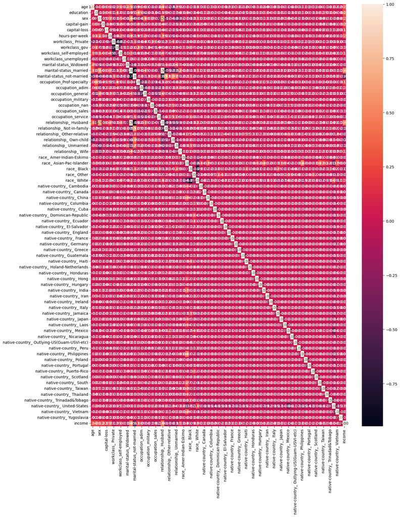

```python
from pylab import rcParams


def plot_correlation(data):
    '''
    plot correlation's matrix to explore dependency between features
    '''
    # init figure size
    rcParams['figure.figsize'] = 15, 20
    fig = plt.figure()
    sns.heatmap(data.corr(), annot=True, fmt=".2f")
    plt.show()
    fig.savefig('corr.png')


# plot correlation & densities
plot_correlation(df)
```

```python
#plt.close();
#sns.set_style("whitegrid");
#sns.pairplot(df, hue="income", height=3);
#plt.show()
```

```python
df.columns
```

```
Index(['age', 'education', 'sex', 'capital-gain', 'capital-loss',
       'hours-per-week', 'workclass_ Private', 'workclass_gov',
       'workclass_self-employed', 'workclass_unemployed',
       'marital-status_Widowed', 'marital-status_married',
       'marital-status_not-married', 'occupation_Prof-specialty',
       'occupation_adim', 'occupation_general', 'occupation_military',
       'occupation_nan', 'occupation_sales', 'occupation_service',
       'relationship_ Husband', 'relationship_ Not-in-family',
       'relationship_ Other-relative', 'relationship_ Own-child',
       'relationship_ Unmarried', 'relationship_ Wife',
       'race_ Amer-Indian-Eskimo', 'race_ Asian-Pac-Islander', 'race_ Black',
       'race_ Other', 'race_ White', 'native-country_ Cambodia',
       'native-country_ Canada', 'native-country_ China',
       'native-country_ Columbia', 'native-country_ Cuba',
       'native-country_ Dominican-Republic', 'native-country_ Ecuador',
       'native-country_ El-Salvador', 'native-country_ England',
       'native-country_ France', 'native-country_ Germany',
       'native-country_ Greece', 'native-country_ Guatemala',
       'native-country_ Haiti', 'native-country_ Holand-Netherlands',
       'native-country_ Honduras', 'native-country_ Hong',
       'native-country_ Hungary', 'native-country_ India',
       'native-country_ Iran', 'native-country_ Ireland',
       'native-country_ Italy', 'native-country_ Jamaica',
       'native-country_ Japan', 'native-country_ Laos',
       'native-country_ Mexico', 'native-country_ Nicaragua',
       'native-country_ Outlying-US(Guam-USVI-etc)', 'native-country_ Peru',
       'native-country_ Philippines', 'native-country_ Poland',
       'native-country_ Portugal', 'native-country_ Puerto-Rico',
       'native-country_ Scotland', 'native-country_ South',
       'native-country_ Taiwan', 'native-country_ Thailand',
       'native-country_ Trinadad&Tobago', 'native-country_ United-States',
       'native-country_ Vietnam', 'native-country_ Yugoslavia', 'income'],
      dtype='object')
```

```python
df.shape
```

```
(30162, 73)
```

```python
X = df[['age', 'education', 'sex', 'capital-gain', 'capital-loss',
       'hours-per-week', 'workclass_ Private', 'workclass_gov',
       'workclass_self-employed', 'workclass_unemployed',
       'marital-status_Widowed', 'marital-status_married',
       'marital-status_not-married', 'occupation_Prof-specialty',
       'occupation_adim', 'occupation_general', 'occupation_military',
       'occupation_nan', 'occupation_sales', 'occupation_service',
       'relationship_ Husband', 'relationship_ Not-in-family',
       'relationship_ Other-relative', 'relationship_ Own-child',
       'relationship_ Unmarried', 'relationship_ Wife',
       'race_ Amer-Indian-Eskimo', 'race_ Asian-Pac-Islander', 'race_ Black',
       'race_ Other', 'race_ White', 'native-country_ Cambodia',
       'native-country_ Canada', 'native-country_ China',
       'native-country_ Columbia', 'native-country_ Cuba',
       'native-country_ Dominican-Republic', 'native-country_ Ecuador',
       'native-country_ El-Salvador', 'native-country_ England',
       'native-country_ France', 'native-country_ Germany',
       'native-country_ Greece', 'native-country_ Guatemala',
       'native-country_ Haiti', 'native-country_ Holand-Netherlands',
       'native-country_ Honduras', 'native-country_ Hong',
       'native-country_ Hungary', 'native-country_ India',
       'native-country_ Iran', 'native-country_ Ireland',
       'native-country_ Italy', 'native-country_ Jamaica',
       'native-country_ Japan', 'native-country_ Laos',
       'native-country_ Mexico', 'native-country_ Nicaragua',
       'native-country_ Outlying-US(Guam-USVI-etc)', 'native-country_ Peru',
       'native-country_ Philippines', 'native-country_ Poland',
       'native-country_ Portugal', 'native-country_ Puerto-Rico',
       'native-country_ Scotland', 'native-country_ South',
       'native-country_ Taiwan', 'native-country_ Thailand',
       'native-country_ Trinadad&Tobago', 'native-country_ United-States',
       'native-country_ Vietnam', 'native-country_ Yugoslavia']].values
X[0:5]
```

```
array([[  39,    4,    1, 2174,    0,   40,    0,    1,    0,    0,    0,
           0,    1,    0,    1,    0,    0,    0,    0,    0,    0,    1,
           0,    0,    0,    0,    0,    0,    0,    0,    1,    0,    0,
           0,    0,    0,    0,    0,    0,    0,    0,    0,    0,    0,
           0,    0,    0,    0,    0,    0,    0,    0,    0,    0,    0,
           0,    0,    0,    0,    0,    0,    0,    0,    0,    0,    0,
           0,    0,    0,    1,    0,    0],
       [  50,    4,    1,    0,    0,   13,    0,    0,    1,    0,    0,
           1,    0,    0,    1,    0,    0,    0,    0,    0,    1,    0,
           0,    0,    0,    0,    0,    0,    0,    0,    1,    0,    0,
           0,    0,    0,    0,    0,    0,    0,    0,    0,    0,    0,
           0,    0,    0,    0,    0,    0,    0,    0,    0,    0,    0,
           0,    0,    0,    0,    0,    0,    0,    0,    0,    0,    0,
           0,    0,    0,    1,    0,    0],
       [  38,    1,    1,    0,    0,   40,    1,    0,    0,    0,    0,
```

[output cut: 20 more lines]

```python
Y = df['income'].values
Y[0:5]
```

```
array([0, 0, 0, 0, 0])
```

## standardizes features

```python
sc = preprocessing.StandardScaler().fit(X)
X = sc.transform(X.astype(float))
X[0:5]
```

```
array([[ 4.27957113e-02,  1.18178500e+00,  6.92806158e-01,
         1.46092284e-01, -2.18585975e-01, -7.77341106e-02,
        -1.68214415e+00,  2.45609619e+00, -3.66577248e-01,
        -2.15493793e-02, -1.67903484e-01, -9.36062492e-01,
         9.88921518e-01, -3.93154562e-01,  1.70603067e+00,
        -6.76457209e-01, -1.72765090e-02, -2.16461260e-01,
        -3.67217062e-01, -3.90959645e-01, -8.39144849e-01,
         1.70410113e+00, -1.74267846e-01, -4.16894915e-01,
        -3.45229885e-01, -2.21120202e-01, -9.78412046e-02,
        -1.74872860e-01, -3.20962622e-01, -8.78507304e-02,
         4.03824313e-01, -2.44363205e-02, -5.96669066e-02,
        -4.75351094e-02, -4.31288109e-02, -5.53129982e-02,
        -4.71835081e-02, -2.99327270e-02, -5.76754597e-02,
        -5.34735710e-02, -2.99327270e-02, -6.52827434e-02,
        -3.10225729e-02, -4.57503311e-02, -3.73419645e-02,
        -5.75807254e-03, -1.99501867e-02, -2.51063491e-02,
        -2.07651571e-02, -5.76754597e-02, -3.73419645e-02,
        -2.82194410e-02, -4.75351094e-02, -5.15693479e-02,
        -4.42711819e-02, -2.37474410e-02, -1.43671782e-01,
        -3.30951696e-02, -2.15493793e-02, -3.15534352e-02,
        -7.91966065e-02, -4.31288109e-02, -3.35934268e-02,
        -6.02239634e-02, -1.91005328e-02, -4.85747824e-02,
        -3.73419645e-02, -2.37474410e-02, -2.44363205e-02,
         3.10870534e-01, -4.61127654e-02, -2.30380196e-02],
       [ 8.80288144e-01,  1.18178500e+00,  6.92806158e-01,
        -1.47444622e-01, -2.18585975e-01, -2.33153070e+00,
        -1.68214415e+00, -4.07150178e-01,  2.72793799e+00,
        -2.15493793e-02, -1.67903484e-01,  1.06830474e+00,
        -1.01120259e+00, -3.93154562e-01,  1.70603067e+00,
        -6.76457209e-01, -1.72765090e-02, -2.16461260e-01,
        -3.67217062e-01, -3.90959645e-01,  1.19168937e+00,
        -5.86819634e-01, -1.74267846e-01, -4.16894915e-01,
        -3.45229885e-01, -2.21120202e-01, -9.78412046e-02,
        -1.74872860e-01, -3.20962622e-01, -8.78507304e-02,
         4.03824313e-01, -2.44363205e-02, -5.96669066e-02,
        -4.75351094e-02, -4.31288109e-02, -5.53129982e-02,
        -4.71835081e-02, -2.99327270e-02, -5.76754597e-02,
        -5.34735710e-02, -2.99327270e-02, -6.52827434e-02,
        -3.10225729e-02, -4.57503311e-02, -3.73419645e-02,
        -5.75807254e-03, -1.99501867e-02, -2.51063491e-02,
```

[output cut: 65 more lines]

```
        -1.74872860e-01,  3.11562759e+00, -8.78507304e-02,
        -2.47632440e+00, -2.44363205e-02, -5.96669066e-02,
        -4.75351094e-02, -4.31288109e-02,  1.80789332e+01,
        -4.71835081e-02, -2.99327270e-02, -5.76754597e-02,
        -5.34735710e-02, -2.99327270e-02, -6.52827434e-02,
        -3.10225729e-02, -4.57503311e-02, -3.73419645e-02,
        -5.75807254e-03, -1.99501867e-02, -2.51063491e-02,
        -2.07651571e-02, -5.76754597e-02, -3.73419645e-02,
        -2.82194410e-02, -4.75351094e-02, -5.15693479e-02,
        -4.42711819e-02, -2.37474410e-02, -1.43671782e-01,
        -3.30951696e-02, -2.15493793e-02, -3.15534352e-02,
        -7.91966065e-02, -4.31288109e-02, -3.35934268e-02,
        -6.02239634e-02, -1.91005328e-02, -4.85747824e-02,
        -3.73419645e-02, -2.37474410e-02, -2.44363205e-02,
        -3.21677320e+00, -4.61127654e-02, -2.30380196e-02]])
```

## splitting data for train and test

```python
from sklearn.model_selection import train_test_split
x_train, x_test, y_train, y_test = train_test_split(X, Y, test_size=0.2, random_state=4)
print('train set : ', x_train.shape, y_train.shape)
print('test set : ', x_test.shape, y_test.shape)
```

```
train set :  (24129, 72) (24129,)
test set :  (6033, 72) (6033,)
```

```python
from sklearn.preprocessing import StandardScaler
```

```python
scaler = StandardScaler().fit(x_train)
x_train_sc = scaler.transform(x_train)

x_test_sc = scaler.transform(x_test)
x_train_sc[0:5]
```

```
array([[ 7.29633899e-01, -1.41112604e+00,  6.92124563e-01,
        -1.49654480e-01, -2.19627094e-01,  2.54264190e-01,
         5.94246755e-01, -4.08317376e-01, -3.65096917e-01,
        -2.13562845e-02, -1.66780219e-01,  1.07120139e+00,
        -1.01465417e+00, -3.91866439e-01, -5.84863867e-01,
         1.47573552e+00, -1.70350088e-02, -2.17406589e-01,
        -3.66626061e-01, -3.92358867e-01,  1.19476558e+00,
        -5.88693059e-01, -1.75000915e-01, -4.17325513e-01,
        -3.44211323e-01, -2.21349813e-01, -9.61445151e-02,
        -1.75000915e-01, -3.22880042e-01, -8.71786495e-02,
         4.04856915e-01, -2.49408357e-02, -5.94574259e-02,
        -4.77977239e-02, -4.27418202e-02, -5.62111112e-02,
        -4.55686097e-02, -2.95140668e-02, -5.83951091e-02,
        -5.35521281e-02, -2.88021826e-02, -6.61107357e-02,
        -3.15538279e-02, -4.46460827e-02, -3.81135647e-02,
        -6.43782753e-03, -1.82115680e-02, -2.03619962e-02,
        -2.23063741e-02, -5.94574259e-02, -3.86550118e-02,
        -3.02092370e-02, -4.73602223e-02, -5.15699908e-02,
        -4.69186781e-02, -2.40946368e-02, -1.46059349e-01,
        -3.28436279e-02, -2.13562845e-02, -3.34699714e-02,
        -7.66677179e-02, -4.32256913e-02, -3.52826435e-02,
        -5.94574259e-02, -1.93166852e-02, -4.95094339e-02,
        -3.58666114e-02, -1.82115680e-02, -2.40946368e-02,
         3.12443417e-01, -4.77977239e-02, -2.32176916e-02],
       [ 1.41502796e+00,  2.46631022e+00,  6.92124563e-01,
        -1.49654480e-01,  4.65776107e+00, -7.80026269e-02,
         5.94246755e-01, -4.08317376e-01, -3.65096917e-01,
        -2.13562845e-02, -1.66780219e-01,  1.07120139e+00,
        -1.01465417e+00, -3.91866439e-01, -5.84863867e-01,
         1.47573552e+00, -1.70350088e-02, -2.17406589e-01,
        -3.66626061e-01, -3.92358867e-01,  1.19476558e+00,
        -5.88693059e-01, -1.75000915e-01, -4.17325513e-01,
        -3.44211323e-01, -2.21349813e-01, -9.61445151e-02,
        -1.75000915e-01, -3.22880042e-01, -8.71786495e-02,
         4.04856915e-01, -2.49408357e-02, -5.94574259e-02,
        -4.77977239e-02, -4.27418202e-02, -5.62111112e-02,
        -4.55686097e-02, -2.95140668e-02, -5.83951091e-02,
        -5.35521281e-02, -2.88021826e-02,  1.51261363e+01,
        -3.15538279e-02, -4.46460827e-02, -3.81135647e-02,
        -6.43782753e-03, -1.82115680e-02, -2.03619962e-02,
```

[output cut: 65 more lines]

```
        -1.75000915e-01, -3.22880042e-01, -8.71786495e-02,
         4.04856915e-01, -2.49408357e-02, -5.94574259e-02,
        -4.77977239e-02, -4.27418202e-02, -5.62111112e-02,
        -4.55686097e-02, -2.95140668e-02, -5.83951091e-02,
        -5.35521281e-02, -2.88021826e-02, -6.61107357e-02,
        -3.15538279e-02, -4.46460827e-02, -3.81135647e-02,
        -6.43782753e-03, -1.82115680e-02, -2.03619962e-02,
        -2.23063741e-02, -5.94574259e-02, -3.86550118e-02,
        -3.02092370e-02, -4.73602223e-02, -5.15699908e-02,
        -4.69186781e-02, -2.40946368e-02, -1.46059349e-01,
        -3.28436279e-02, -2.13562845e-02, -3.34699714e-02,
        -7.66677179e-02, -4.32256913e-02, -3.52826435e-02,
        -5.94574259e-02, -1.93166852e-02, -4.95094339e-02,
        -3.58666114e-02, -1.82115680e-02, -2.40946368e-02,
         3.12443417e-01, -4.77977239e-02, -2.32176916e-02]])
```

## KNN Classifier

```python
from sklearn.neighbors import KNeighborsClassifier
```

```python
k=4
neigh = KNeighborsClassifier(n_neighbors=k).fit(x_train_sc, y_train)
neigh
```

```
KNeighborsClassifier(n_neighbors=4)
```

```python
yhat = neigh.predict(x_test_sc)
yhat[0:5]
```

```
array([0, 0, 0, 0, 1])
```

```python
from sklearn import metrics
```

## checking accuracy

```python
score = metrics.accuracy_score(y_test, yhat)
print('train set accuracy: ', metrics.accuracy_score(y_train, neigh.predict(x_train_sc)))
print('test set accuracy: ', score)
```

```
train set accuracy:  0.8716896680343156
test set accuracy:  0.8112050389524283
```

```python
ks=12
mean_acc = np.zeros(ks-1)
std_acc = np.zeros(ks-1)
k_values = np.zeros(ks-1)

for n in range(1,ks):
    k_values[n-1] = n
    neigh = KNeighborsClassifier(n_neighbors=n).fit(x_train_sc, y_train)
    yhat = neigh.predict(x_test_sc)
    mean_acc[n-1] = metrics.accuracy_score(y_test, yhat)

    std_acc[n-1] = np.std(yhat==y_test)/np.sqrt(yhat.shape[0])

mean_acc
```

```
array([0.78949113, 0.80242002, 0.80623239, 0.81120504, 0.81468589,
       0.81452014, 0.81800099, 0.81518316, 0.81932703, 0.81849826,
       0.82231062])
```

```python
std_acc
```

```
array([0.00524858, 0.00512632, 0.00508867, 0.00503841, 0.00500245,
       0.00500418, 0.00496758, 0.00499726, 0.00495346, 0.0049623 ,
       0.00492132])
```

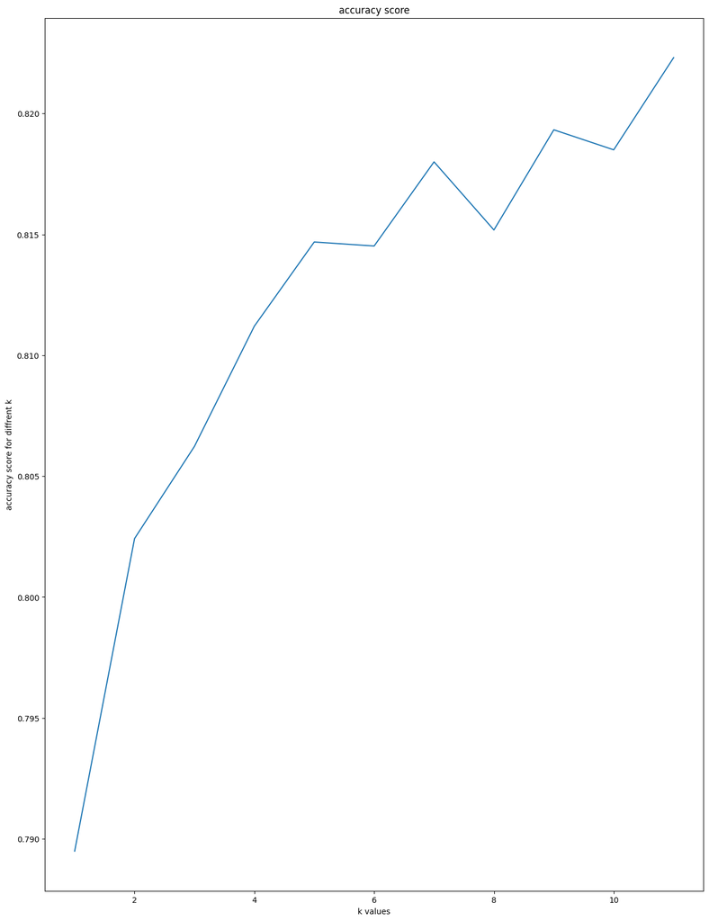

```python
plt.plot(k_values, mean_acc)
plt.title('accuracy score')
plt.xlabel('k values')
plt.ylabel('accuracy score for diffrent k')
plt.show()
```

## confusion_matrix

```python
from sklearn.metrics import confusion_matrix
from sklearn.metrics import ConfusionMatrixDisplay
```

```python
cm = confusion_matrix(y_test,yhat)
cm
```

```
array([[4135,  386],
       [ 686,  826]])
```

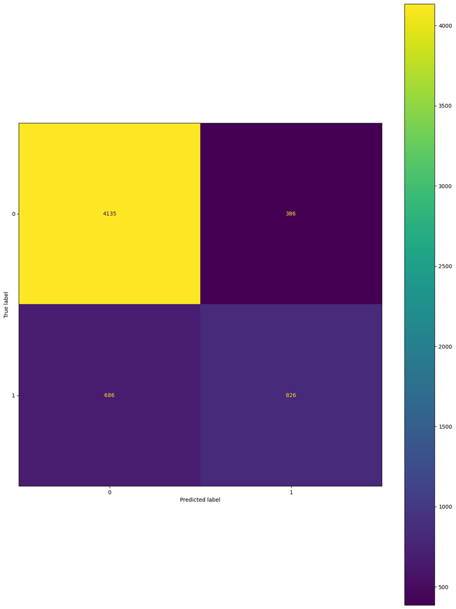

```python
cm = confusion_matrix(y_test, yhat, labels=neigh.classes_)
disp = ConfusionMatrixDisplay(confusion_matrix=cm,
                              display_labels=neigh.classes_)
disp.plot()

plt.show()
```

## result is not very good. It seems because of the data is imbalance

## resampling

```python
from imblearn.over_sampling import SMOTE
smote = SMOTE(sampling_strategy='minority')
x_sm, y_sm = smote.fit_resample(x_train, y_train)
```

```python
x_sm.shape
```

```
(36266, 72)
```

```python
scaler = StandardScaler().fit(x_sm)
x_train_sm_sc = scaler.transform(x_sm)

x_train_sm_sc[0:5]
```

```
array([[ 6.32962763e-01, -1.54669339e+00,  6.03427256e-01,
        -1.94828930e-01, -2.62490510e-01,  1.34468528e-01,
         6.36885223e-01, -4.25091694e-01, -3.95844713e-01,
        -1.74185656e-02, -1.49429010e-01,  8.23087087e-01,
        -7.86293056e-01, -4.54447101e-01, -6.28656754e-01,
         1.56897912e+00, -1.38944420e-02, -1.87599311e-01,
        -3.72442550e-01, -3.39987043e-01,  9.47649893e-01,
        -5.11676525e-01, -1.47709181e-01, -3.35021520e-01,
        -2.96402116e-01, -2.60043410e-01, -8.83487016e-02,
        -1.77121319e-01, -2.93361754e-01, -7.72085637e-02,
         3.75048347e-01, -2.67850573e-02, -6.37956121e-02,
        -5.33686708e-02, -3.51831915e-02, -5.64012543e-02,
        -3.78837019e-02, -2.75726930e-02, -5.28465271e-02,
        -5.88105071e-02, -3.19574920e-02, -7.42799373e-02,
        -3.23869178e-02, -3.81402855e-02, -3.28024282e-02,
        -5.25117098e-03, -1.48539881e-02, -1.66077216e-02,
        -2.12310075e-02, -6.46613346e-02, -4.00231926e-02,
        -2.64645561e-02, -4.76045691e-02, -4.73127532e-02,
        -4.78946231e-02, -2.09915851e-02, -1.24846695e-01,
        -2.78011585e-02, -1.74185656e-02, -2.72956713e-02,
        -7.81236996e-02, -4.20459050e-02, -3.27324926e-02,
        -5.41425519e-02, -1.76663161e-02, -4.49106291e-02,
        -4.07085236e-02, -1.57552508e-02, -2.17664984e-02,
         2.97160785e-01, -4.18424779e-02, -2.27260742e-02],
       [ 1.36622394e+00,  2.25181325e+00,  6.03427256e-01,
        -1.94828930e-01,  3.86454760e+00, -2.14813407e-01,
         6.36885223e-01, -4.25091694e-01, -3.95844713e-01,
        -1.74185656e-02, -1.49429010e-01,  8.23087087e-01,
        -7.86293056e-01, -4.54447101e-01, -6.28656754e-01,
         1.56897912e+00, -1.38944420e-02, -1.87599311e-01,
        -3.72442550e-01, -3.39987043e-01,  9.47649893e-01,
        -5.11676525e-01, -1.47709181e-01, -3.35021520e-01,
        -2.96402116e-01, -2.60043410e-01, -8.83487016e-02,
        -1.77121319e-01, -2.93361754e-01, -7.72085637e-02,
         3.75048347e-01, -2.67850573e-02, -6.37956121e-02,
        -5.33686708e-02, -3.51831915e-02, -5.64012543e-02,
        -3.78837019e-02, -2.75726930e-02, -5.28465271e-02,
        -5.88105071e-02, -3.19574920e-02,  1.34625854e+01,
        -3.23869178e-02, -3.81402855e-02, -3.28024282e-02,
        -5.25117098e-03, -1.48539881e-02, -1.66077216e-02,
```

[output cut: 65 more lines]

```
        -1.77121319e-01, -2.93361754e-01, -7.72085637e-02,
         3.75048347e-01, -2.67850573e-02, -6.37956121e-02,
        -5.33686708e-02, -3.51831915e-02, -5.64012543e-02,
        -3.78837019e-02, -2.75726930e-02, -5.28465271e-02,
        -5.88105071e-02, -3.19574920e-02, -7.42799373e-02,
        -3.23869178e-02, -3.81402855e-02, -3.28024282e-02,
        -5.25117098e-03, -1.48539881e-02, -1.66077216e-02,
        -2.12310075e-02, -6.46613346e-02, -4.00231926e-02,
        -2.64645561e-02, -4.76045691e-02, -4.73127532e-02,
        -4.78946231e-02, -2.09915851e-02, -1.24846695e-01,
        -2.78011585e-02, -1.74185656e-02, -2.72956713e-02,
        -7.81236996e-02, -4.20459050e-02, -3.27324926e-02,
        -5.41425519e-02, -1.76663161e-02, -4.49106291e-02,
        -4.07085236e-02, -1.57552508e-02, -2.17664984e-02,
         2.97160785e-01, -4.18424779e-02, -2.27260742e-02]])
```

```python
#from sklearn.model_selection import train_test_split
#x_train, x_test, y_train, y_test = train_test_split(x_sm, y_sm, test_size=0.2, random_state=4)
#print('train set : ', x_train.shape, y_train.shape)
#print('test set : ', x_test.shape, y_test.shape)
```

```python
ks=5
mean_acc = np.zeros(ks-1)
std_acc = np.zeros(ks-1)
k_values = np.zeros(ks-1)

for n in range(1,ks):
    k_values[n-1] = n
    neigh = KNeighborsClassifier(n_neighbors=n).fit(x_train_sm_sc, y_sm)
    yhat = neigh.predict(x_test_sc)
    mean_acc[n-1] = metrics.accuracy_score(y_test, yhat)

    std_acc[n-1] = np.std(yhat==y_test)/np.sqrt(yhat.shape[0])

mean_acc
```

```
array([0.75849494, 0.77540196, 0.75832919, 0.78087187])
```

```python
std_acc
```

```
array([0.00551027, 0.00537279, 0.00551156, 0.00532565])
```

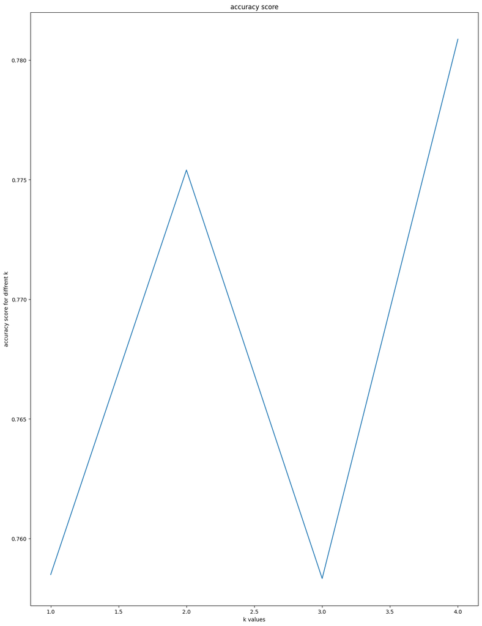

```python
plt.plot(k_values, mean_acc)
plt.title('accuracy score')
plt.xlabel('k values')
plt.ylabel('accuracy score for diffrent k')
plt.show()
```

```python
cm = confusion_matrix(y_test,yhat)
cm
```

```
array([[3679,  842],
       [ 480, 1032]])
```

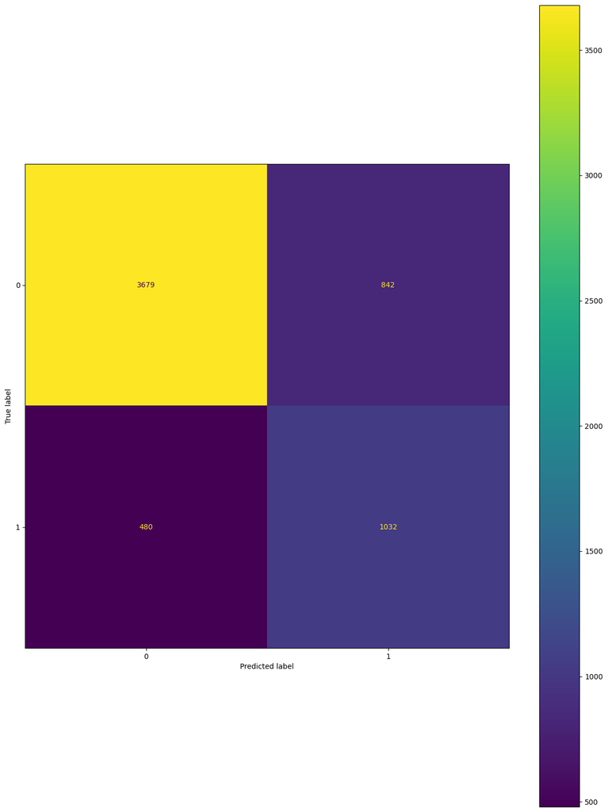

```python
cm = confusion_matrix(y_test, yhat, labels=neigh.classes_)
disp = ConfusionMatrixDisplay(confusion_matrix=cm,
                              display_labels=neigh.classes_)
disp.plot()

plt.show()
```

```python
from sklearn.decomposition import PCA
```

```python
pca = PCA()
X = pca.fit_transform(X)
```

```python
explained_variance = pca.explained_variance_ratio_
explained_variance
```

```
array([5.79571725e-02, 3.52399993e-02, 3.24968329e-02, 2.52870074e-02,
       2.31687439e-02, 2.25710701e-02, 2.11493986e-02, 1.92309565e-02,
       1.79203093e-02, 1.74537062e-02, 1.66380593e-02, 1.61236900e-02,
       1.57505097e-02, 1.52322815e-02, 1.48895960e-02, 1.47365892e-02,
       1.45378297e-02, 1.41957764e-02, 1.41141798e-02, 1.40788879e-02,
       1.39982388e-02, 1.39807920e-02, 1.39499578e-02, 1.39401659e-02,
       1.39338989e-02, 1.39320767e-02, 1.39219802e-02, 1.39193668e-02,
       1.39166098e-02, 1.39136552e-02, 1.39122280e-02, 1.39099308e-02,
       1.39086435e-02, 1.39072973e-02, 1.39049212e-02, 1.39042376e-02,
       1.39025376e-02, 1.39018555e-02, 1.39002515e-02, 1.38974272e-02,
       1.38961068e-02, 1.38921381e-02, 1.38878212e-02, 1.38748057e-02,
       1.38576761e-02, 1.38371452e-02, 1.38155953e-02, 1.37930986e-02,
       1.37463666e-02, 1.37307440e-02, 1.36973168e-02, 1.36259684e-02,
       1.34968324e-02, 1.33274044e-02, 1.28964681e-02, 1.27336244e-02,
       1.23985109e-02, 1.21155495e-02, 1.15019359e-02, 1.05350611e-02,
       1.01595341e-02, 7.77980958e-03, 7.21060589e-03, 5.27889897e-03,
       3.38188297e-03, 3.00430647e-04, 4.03323484e-31, 2.79470471e-31,
       5.14878697e-32, 4.79420908e-32, 4.01140094e-32, 2.01631962e-32])
```

```python
pca = PCA(n_components=7)
x_train_pca = pca.fit_transform(x_sm)
x_test_pca = pca.transform(x_test)
x_train_pca[0:5]
```

```
array([[ 1.43169768, -0.59097965, -2.23928972, -0.0139588 ,  0.10563559,
        -0.72490462,  0.08336794],
       [ 2.41599741,  2.49651627, -1.38789926, -1.14411502,  0.15726729,
         5.33329392,  4.52697525],
       [ 1.17308963, -0.56946363, -2.17694713, -0.03964841,  0.19770079,
        -0.40739446, -0.14309468],
       [ 2.23354063, -0.5340131 ,  0.68346279, -0.29049687, -0.92466716,
        -0.73186298,  0.98450889],
       [ 0.58831779,  0.20894241,  2.89002152, -2.71907578,  3.72990137,
         2.27709668, -0.72377956]])
```

```python
scaler = StandardScaler().fit(x_train_pca)
x_train_pca_sc = scaler.transform(x_train_pca)

x_test_pca_sc = scaler.transform(x_test_pca)
x_train_pca_sc[0:5]
```

```
array([[ 0.71185423, -0.37215492, -1.44428711, -0.00990895,  0.07803398,
        -0.5625604 ,  0.06643613],
       [ 1.20125779,  1.57211981, -0.89516108, -0.81217405,  0.11617479,
         4.13888926,  3.60755865],
       [ 0.58327176, -0.35860574, -1.40407766, -0.02814526,  0.14604339,
        -0.31615744, -0.11403254],
       [ 1.11053848, -0.33628163,  0.44081679, -0.2062153 , -0.6830601 ,
        -0.56796042,  0.78455776],
       [ 0.29251742,  0.13157635,  1.8639932 , -1.93019298,  2.7553123 ,
         1.76713512, -0.57678186]])
```

```python
k=4
neigh_pca = KNeighborsClassifier(n_neighbors=k).fit(x_train_pca_sc, y_sm)
neigh_pca
```

```
KNeighborsClassifier(n_neighbors=4)
```

```python
yhat_pca = neigh_pca.predict(x_test_pca_sc)
yhat_pca[0:5]
```

```
array([0, 0, 0, 0, 1])
```

```python
y_test.shape
```

```
(6033,)
```

```python
yhat_pca.shape
```

```
(6033,)
```

```python
score = metrics.accuracy_score(y_test, yhat_pca)
print('train set accuracy: ', metrics.accuracy_score(y_sm, neigh_pca.predict(x_train_pca_sc)))
print('test set accuracy: ', score)
```

```
train set accuracy:  0.8973970109744664
test set accuracy:  0.7961213326703133
```

```python
cm = confusion_matrix(y_test,yhat_pca)
cm
```

```
array([[3811,  710],
       [ 520,  992]])
```